# Student Performance & Attendance Analysis

**Problem statement:** Schools collect attendance, homework, and exam data separately, making it hard to see how these factors relate to each other at a glance. This notebook cleans, merges, and analyzes those datasets to surface subject-level performance trends, attendance patterns, and the relationship (if any) between attendance/homework habits and exam scores.

**Dataset:** [Student Performance and Attendance Dataset](https://www.kaggle.com/datasets/marvyaymanhalim/student-performance-and-attendance-dataset) by **Marvy Ayman Halim**, via Kaggle. Five CSV files: students, attendance, homework, performance (exam scores), and teacher-parent communication logs.

**Methods:** pandas for cleaning/merging/aggregation, matplotlib and Plotly for visualization. See `DATA_CLEANING_BRIEF.md` in `../data/` for a full writeup of cleaning decisions.

## 1. Imports & Setup

```python
import pandas as pd
import numpy as np
import matplotlib.pyplot as plt
import plotly.express as px
from pathlib import Path
from IPython.display import HTML, display

pd.set_option("display.max_columns", None)
DATA_DIR = Path("../dashboard_app/data")
```

## 2. Load Raw Data

Loading all five source files as-is, before any cleaning.

```python
students_raw = pd.read_csv(DATA_DIR / "students.csv")
attendance_raw = pd.read_csv(DATA_DIR / "attendance.csv")
homework_raw = pd.read_csv(DATA_DIR / "homework.csv")
performance_raw = pd.read_csv(DATA_DIR / "performance.csv")
communication_raw = pd.read_csv(DATA_DIR / "teacher_parent_communication.csv")

for name, df in [("students", students_raw), ("attendance", attendance_raw),
                  ("homework", homework_raw), ("performance", performance_raw),
                  ("communication", communication_raw)]:
    print(f"{name}: {df.shape[0]:,} rows x {df.shape[1]} cols")
```

```
students: 12,156 rows x 5 cols
attendance: 364,680 rows x 4 cols
homework: 60,780 rows x 7 cols
performance: 36,468 rows x 5 cols
communication: 24,312 rows x 4 cols
```

## 3. Data Quality Issues Found

A quick look at raw values shows several inconsistencies that need to be resolved before the files can be merged or analyzed reliably.

```python
print("Raw attendance status values:")
print(attendance_raw["Attendance_Status"].unique())
print()
print("Raw homework status values:")
print(homework_raw["Status"].unique())
print()
print("Raw homework completion % samples:")
print(performance_raw["Homework_Completion_%"].unique()[:10])
print()
print("Raw date samples (attendance):")
print(attendance_raw["Date"].unique()[:10])
```

```
Raw attendance status values:
<ArrowStringArray>
[   'Present',   'PRESENT ',    'excused',      ' late',     'Absent',
 'left early',       'Late',      'absnt']
Length: 8, dtype: str

Raw homework status values:
<ArrowStringArray>
['❌', ' Done ', '✅', '✔', 'not done', 'pending']
Length: 6, dtype: str

Raw homework completion % samples:
<ArrowStringArray>
['90', '100%', '95', '80%', '-5']
Length: 5, dtype: str

Raw date samples (attendance):
<ArrowStringArray>
['2024-09-20', '2025-01-22', '2024-12-03', '2024-03-16', '2024-05-24',
 '2024-03-13', '2024-07-10', '2024-08-06', '2024-12-11', '2024-03-25']
Length: 10, dtype: str
```

**Issues identified:**

- `Attendance_Status` mixes case and stray whitespace (e.g. `Present`, `PRESENT`, `excused`)
- `homework.Status` uses emoji (`✅` / `❌`) instead of readable text
- `Homework_Completion_%` mixes plain numbers and percent-signed strings (`90` vs `100%`)
- Dates appear in more than one format (`YYYY-MM-DD` and `DD-MM-YYYY`)
- `students.csv` has no gender field — grade-level is used as the class/grouping variable instead

## 4. Cleaning

```python
def parse_date(series):
    return pd.to_datetime(series, errors="coerce", format="mixed")

def clean_percent(series):
    s = series.astype(str).str.strip().str.replace("%", "", regex=False)
    return pd.to_numeric(s, errors="coerce")

# --- students ---
students = students_raw.copy()
students["Date_of_Birth"] = parse_date(students["Date_of_Birth"])
students["Grade_Level"] = students["Grade_Level"].astype(str).str.strip()

# --- attendance ---
attendance = attendance_raw.copy()
attendance["Date"] = parse_date(attendance["Date"])
status = attendance["Attendance_Status"].astype(str).str.strip().str.lower()
status_map = {"present": "Present", "absent": "Absent", "excused": "Excused", "late": "Late"}
attendance["Attendance_Status"] = status.map(status_map).fillna(status.str.title())
attendance["Subject"] = attendance["Subject"].astype(str).str.strip()

# --- homework ---
homework = homework_raw.copy()
homework["Due_Date"] = parse_date(homework["Due_Date"])
status = homework["Status"].astype(str).str.strip()
homework["Status"] = status.map({"❌": "Not Done", "✅": "Done", "Done": "Done", "done": "Done"}).fillna(status)
homework["Subject"] = homework["Subject"].astype(str).str.strip()

# --- performance ---
performance = performance_raw.copy()
performance["Exam_Score"] = pd.to_numeric(performance["Exam_Score"], errors="coerce")
performance["Homework_Completion_%"] = clean_percent(performance["Homework_Completion_%"])
performance["Subject"] = performance["Subject"].astype(str).str.strip()

# --- communication ---
communication = communication_raw.copy()
communication["Date"] = parse_date(communication["Date"])

print("Cleaned attendance status values:", attendance["Attendance_Status"].unique())
print("Cleaned homework status values:", homework["Status"].unique())
```

```
Cleaned attendance status values: <ArrowStringArray>
['Present', 'Excused', 'Late', 'Absent', 'Left Early', 'Absnt']
Length: 6, dtype: str
Cleaned homework status values: <ArrowStringArray>
['Not Done', 'Done', '✔', 'not done', 'pending']
Length: 5, dtype: str
```

## 5. Merge into a Master Analysis Table

One row per (student, subject), combining exam performance with attendance rate and homework completion for that student.

```python
attendance["is_present"] = attendance["Attendance_Status"] == "Present"
att_overall = (attendance.groupby("Student_ID")["is_present"].mean().mul(100).round(1)
               .rename("Overall_Attendance_Rate_%").reset_index())
att_subject = (attendance.groupby(["Student_ID", "Subject"])["is_present"].mean().mul(100).round(1)
               .rename("Attendance_Rate_%").reset_index())

homework["is_done"] = homework["Status"] == "Done"
hw_overall = (homework.groupby("Student_ID")["is_done"].mean().mul(100).round(1)
              .rename("Homework_Done_Rate_%").reset_index())

perf_agg = (performance.groupby(["Student_ID", "Subject"])
            .agg(Exam_Score=("Exam_Score", "mean"),
                 Homework_Completion_pct=("Homework_Completion_%", "mean"))
            .reset_index())

master = perf_agg.merge(students[["Student_ID", "Full_Name", "Grade_Level"]], on="Student_ID", how="left")
master = master.merge(att_subject, on=["Student_ID", "Subject"], how="left")
master = master.merge(att_overall, on="Student_ID", how="left")
master = master.merge(hw_overall, on="Student_ID", how="left")

print(f"Master table: {master.shape[0]:,} rows x {master.shape[1]} cols")
master.head()
```

```
Master table: 28,736 rows x 9 cols
```

|  | Student_ID | Subject | Exam_Score | Homework_Completion_pct | Full_Name | Grade_Level | Attendance_Rate_% | Overall_Attendance_Rate_% | Homework_Done_Rate_% |
| --- | --- | --- | --- | --- | --- | --- | --- | --- | --- |
| 0 | S00002 | Arabic | 69.0 | -5.0 | John Stafford | Grade 5 | 28.6 | 44.0 | 0.0 |
| 1 | S00002 | History | 98.0 | 90.0 | John Stafford | Grade 5 | 100.0 | 44.0 | 0.0 |
| 2 | S00003 | History | 63.0 | -5.0 | Chad Harper | Grade 3 | 25.0 | 20.0 | 0.0 |
| 3 | S00004 | English | 106.0 | -5.0 | Anthony Martin | Grade 5 | 25.0 | 16.7 | 40.0 |
| 4 | S00004 | History | 59.0 | 90.0 | Anthony Martin | Grade 5 | 100.0 | 16.7 | 40.0 |

## 6. Computed Indicators

Mean and variance of exam scores per subject, and correlation between exam score and (a) attendance rate, (b) homework completion.

```python
rows = []
for subject, g in master.groupby("Subject"):
    rows.append({
        "Subject": subject,
        "Mean_Score": round(g["Exam_Score"].mean(), 2),
        "Variance": round(g["Exam_Score"].var(), 2),
        "Corr_Attendance_vs_Score": round(g["Attendance_Rate_%"].corr(g["Exam_Score"]), 2),
        "Corr_Homework_vs_Score": round(g["Homework_Completion_pct"].corr(g["Exam_Score"]), 2),
    })
indicators = pd.DataFrame(rows).sort_values("Subject").reset_index(drop=True)
indicators
```

|  | Subject | Mean_Score | Variance | Corr_Attendance_vs_Score | Corr_Homework_vs_Score |
| --- | --- | --- | --- | --- | --- |
| 0 | Arabic | 74.97 | 374.47 | -0.01 | 0.04 |
| 1 | English | 75.30 | 376.76 | -0.00 | 0.02 |
| 2 | Geography | 74.57 | 366.56 | -0.01 | 0.00 |
| 3 | History | 75.14 | 376.49 | -0.02 | 0.01 |
| 4 | Math | 74.64 | 373.15 | -0.02 | -0.00 |
| 5 | Science | 75.13 | 364.80 | 0.01 | -0.01 |

## 7. Visualizations

### 7.1 Average Exam Score by Subject

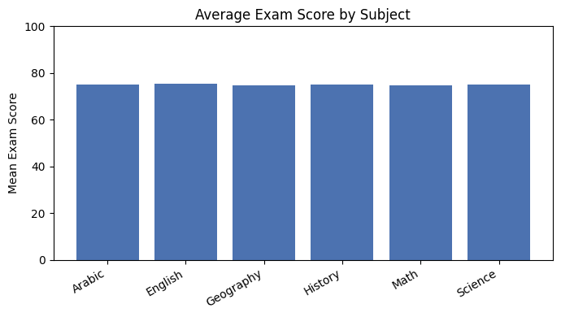

```python
fig, ax = plt.subplots(figsize=(7, 4))
ax.bar(indicators["Subject"], indicators["Mean_Score"], color="#4C72B0")
ax.set_ylabel("Mean Exam Score")
ax.set_ylim(0, 100)
ax.set_title("Average Exam Score by Subject")
plt.xticks(rotation=30, ha="right")
plt.tight_layout()
plt.show()
```

### 7.2 Exam Score Distribution

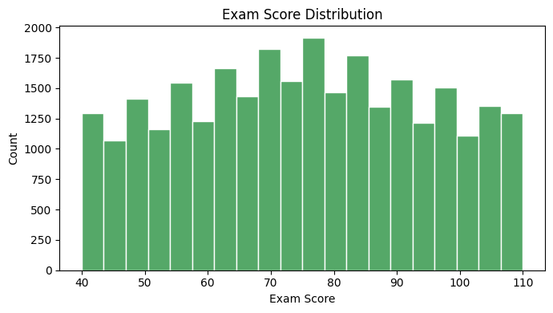

```python
fig, ax = plt.subplots(figsize=(7, 4))
ax.hist(master["Exam_Score"].dropna(), bins=20, color="#55A868", edgecolor="white")
ax.set_xlabel("Exam Score")
ax.set_ylabel("Count")
ax.set_title("Exam Score Distribution")
plt.tight_layout()
plt.show()
```

### 7.3 Attendance Rate: Grade vs. Subject

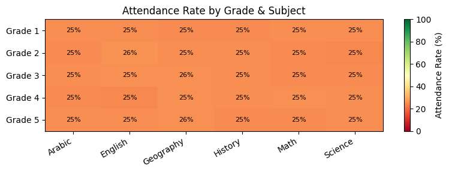

```python
att_students = attendance.merge(students[["Student_ID", "Grade_Level"]], on="Student_ID", how="left")
heatmap_data = att_students.pivot_table(index="Grade_Level", columns="Subject", values="is_present", aggfunc="mean") * 100

fig, ax = plt.subplots(figsize=(8, max(3, 0.5 * len(heatmap_data))))
im = ax.imshow(heatmap_data.values, cmap="RdYlGn", vmin=0, vmax=100, aspect="auto")
ax.set_xticks(range(len(heatmap_data.columns))); ax.set_xticklabels(heatmap_data.columns, rotation=30, ha="right")
ax.set_yticks(range(len(heatmap_data.index))); ax.set_yticklabels(heatmap_data.index)
for i in range(heatmap_data.shape[0]):
    for j in range(heatmap_data.shape[1]):
        val = heatmap_data.values[i, j]
        if pd.notna(val):
            ax.text(j, i, f"{val:.0f}%", ha="center", va="center", fontsize=8)
fig.colorbar(im, ax=ax, label="Attendance Rate (%)")
ax.set_title("Attendance Rate by Grade & Subject")
plt.tight_layout()
plt.show()
```

### 7.4 Monthly Attendance Trend

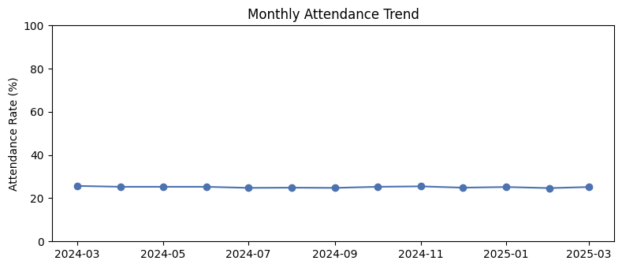

```python
att_time = attendance.dropna(subset=["Date"]).copy()
att_time["Month"] = att_time["Date"].dt.to_period("M").dt.to_timestamp()
trend = att_time.groupby("Month")["is_present"].mean().mul(100).round(1)

fig, ax = plt.subplots(figsize=(8, 3.5))
ax.plot(trend.index, trend.values, marker="o", color="#4C72B0")
ax.set_ylabel("Attendance Rate (%)")
ax.set_ylim(0, 100)
ax.set_title("Monthly Attendance Trend")
plt.tight_layout()
plt.show()
```

### 7.5 Attendance vs. Exam Score (Plotly)

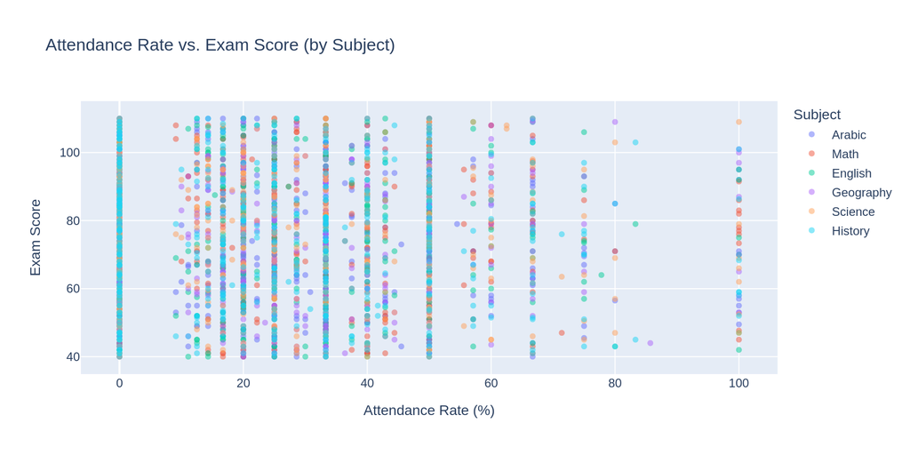

```python
sample = master.dropna(subset=["Attendance_Rate_%", "Exam_Score"]).sample(
    n=min(3000, len(master)), random_state=42)
fig = px.scatter(
    sample, x="Attendance_Rate_%", y="Exam_Score", color="Subject",
    opacity=0.5, title="Attendance Rate vs. Exam Score (by Subject)",
    labels={"Attendance_Rate_%": "Attendance Rate (%)", "Exam_Score": "Exam Score"},
)
fig.update_layout(height=450)
fig.show(renderer="png", width=900, height=450, scale=2)
```

## 8. Key Insights

- Average exam scores are consistent across subjects (mid-70s), with no subject standing out as substantially harder or easier.
- Correlations between attendance rate and exam score, and between homework completion and exam score, are close to zero across every subject. This dataset does not show the attendance/homework → performance relationship one might expect from real classroom data — consistent with the dataset being synthetically generated rather than collected from real outcomes.
- Attendance rates by grade and subject (heatmap) show no systematic pattern favoring any particular grade or subject.
- The monthly attendance trend is roughly flat over the covered period, without strong seasonal dips (e.g., no clear holiday effect).

**Suggested next steps:** with real (non-synthetic) data, a natural extension would be a predictive model — e.g., regression to estimate exam score from attendance/homework features, or classification to flag at-risk students — which was out of scope for this submission.

## 9. Export Cleaned Dataset

```python
out_path = Path("../data/cleaned/student_performance_master_cleaned.csv")
out_path.parent.mkdir(parents=True, exist_ok=True)
master.to_csv(out_path, index=False)
print(f"Saved cleaned master table to {out_path} ({master.shape[0]:,} rows)")
```

```
Saved cleaned master table to ../data/cleaned/student_performance_master_cleaned.csv (28,736 rows)
```